# PML

Eugene Gadeev

24 августа 2015 г.

# Background

Using devices such as Jawbone Up, Nike FuelBand, and Fitbit it is now possible to collect a large amount of data about personal activity relatively inexpensively. These type of devices are part of the quantified self movement – a group of enthusiasts who take measurements about themselves regularly to improve their health, to find patterns in their behavior, or because they are tech geeks. One thing that people regularly do is quantify how much of a particular activity they do, but they rarely quantify how well they do it. In this project, your goal will be to use data from accelerometers on the belt, forearm, arm, and dumbell of 6 participants. They were asked to perform barbell lifts correctly and incorrectly in 5 different ways. More information is available from the website here: http://groupware.les.inf.puc-rio.br/har (see the section on the Weight Lifting Exercise Dataset).

# Data

The training data for this project are available [here](https://d396qusza40orc.cloudfront.net/predmachlearn/pml-training.csv).

The test data are available [here](https://d396qusza40orc.cloudfront.net/predmachlearn/pml-testing.csv).

The data for this project come from this source: http://groupware.les.inf.puc-rio.br/har. If you use the document you create for this class for any purpose please cite them as they have been very generous in allowing their data to be used for this kind of assignment.

# Data Preprocessing

```r
setwd('D:/Users/Eugene/Documents')

train_data <- read.csv("pml-training.csv", na.strings=c("NA",""))

test_data <- read.csv("pml-testing.csv", na.strings=c("NA",""))

train_data <-train_data[,colSums(is.na(train_data)) == 0]
test_data <-test_data[,colSums(is.na(test_data)) == 0]

train_data   <-train_data[,-c(1:7)]
test_data <-test_data[,-c(1:7)]

dim(train_data)
```

```
## [1] 19622    53
```

```r
dim(test_data)
```

```
## [1] 20 53
```

# Partitioning and Train Control

```r
# partition the data
training_dp <- createDataPartition(train_data$classe, p = 0.7, list = FALSE)
training_part <- train_data[training_dp, ]
testing_part <- train_data[-training_dp, ]

# set classe as factor
training_part$classe <- as.factor(training_part$classe)
testing_part$classe <- as.factor(testing_part$classe)

# create an empty numeric vector to calculate out of sample error against
outOfSampleError <- numeric()

# add some parameters for train control
TC <- trainControl(method = "cv", number = 12, returnData=FALSE, returnResamp="none", savePredictions=FALSE, verboseIter=FALSE , preProcOptions="pca", allowParallel=TRUE)
```

# Look at the Data

The variable “classe” contains 5 levels: A, B, C, D and E. A plot of the outcome variable will allow us to see the frequency of each levels in the subTraining data set and compare one another.

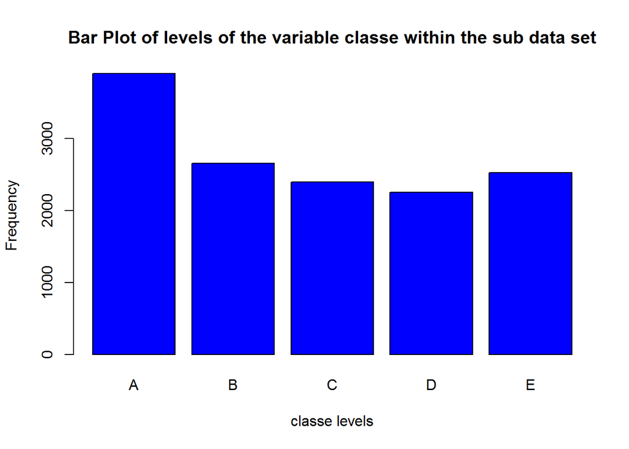

```r
plot(training_part$classe, col="blue", main="Bar Plot of levels of the variable classe within the sub data set", xlab="classe levels", ylab="Frequency")
```

# Build Models

Now it is time to train the data. In order to get a wide range of results we will be using several types: bayesglm (Bayesian GLM), gbm (Generalized Boosted Regression), knn (K Nearest Neighbor), nb (Naive Bayes), nnet (Neural Net), rf (Random Forest), rpart (Recursive Partitioning and Regression Trees), svmLinear (Support Vector Machines Linear), svmRadial (Support Vector Machines Radial), and treebag (Bagged Classification and Regression Trees). Once each of the train methods finishes we will follow it with a prediction and accuracy function. Finally, before moving to the next train function we will calculate the out of sample error for that training method.

```r
# train, predict, calculate accuracy and out of sample error
bayesglm <- train(classe ~ ., method="bayesglm", data=training_part, trControl= TC)
bayesglmPrediction <- predict(bayesglm, testing_part)
bayesglmAccuracy <- sum(bayesglmPrediction == testing_part$classe) / length(bayesglmPrediction)
bayesglmOutOfSampleError <- c(outOfSampleError, 1-bayesglmAccuracy)

gbm <- train(classe ~ ., method="gbm", data=training_part, trControl= TC)
gbmPrediction <- predict(gbm, testing_part)
gbmAccuracy <- sum(gbmPrediction == testing_part$classe) / length(gbmPrediction)
gbmOutOfSampleError <- c(outOfSampleError, 1-gbmAccuracy)

knn <- train(classe ~ ., method="knn", data=training_part, trControl= TC)
knnPrediction <- predict(knn, testing_part)
knnAccuracy <- sum(knnPrediction == testing_part$classe) / length(knnPrediction)
knnOutOfSampleError <- c(outOfSampleError, 1-knnAccuracy)

nb <- train(classe ~ ., method="nb", data=training_part, trControl= TC)
nbPrediction <- predict(nb, testing_part)
```

```r
nbAccuracy <- sum(nbPrediction == testing_part$classe) / length(nbPrediction)
nbOutOfSampleError <- c(outOfSampleError, 1-nbAccuracy)

nnet <- train(classe ~ ., method="nnet", data=training_part, trControl= TC)
nnetPrediction <- predict(nnet, testing_part)
nnetAccuracy <- sum(nnetPrediction == testing_part$classe) / length(nnetPrediction)
nnetOutOfSampleError <- c(outOfSampleError, 1-nnetAccuracy)

rf <- train(classe ~ ., method="rf", data=training_part, trControl= TC)
rfPrediction <- predict(rf, testing_part)
rfAccuracy <- sum(rfPrediction == testing_part$classe) / length(rfPrediction)
rfOutOfSampleError <- c(outOfSampleError, 1-rfAccuracy)

rpart <- train(classe ~ ., method="rpart", data=training_part, trControl= TC)
rpartPrediction <- predict(rpart, testing_part)
rpartAccuracy <- sum(rpartPrediction == testing_part$classe) / length(rpartPrediction)
rpartOutOfSampleError <- c(outOfSampleError, 1-rpartAccuracy)

svml <- train(classe ~ ., method="svmLinear", data=training_part, trControl= TC)
svmlPrediction <- predict(svml, testing_part)
svmlAccuracy <- sum(svmlPrediction == testing_part$classe) / length(svmlPrediction)
svmlOutOfSampleError <- c(outOfSampleError, 1-svmlAccuracy)

svmr <- train(classe ~ ., method="svmRadial", data=training_part, trControl= TC)
svmrPrediction <- predict(svmr, testing_part)
svmrAccuracy <- sum(svmrPrediction == testing_part$classe) / length(svmrPrediction)
svmrOutOfSampleError <- c(outOfSampleError, 1-svmrAccuracy)

treebag <- train(classe ~ ., method="treebag", data=training_part, trControl= TC)
treebagPrediction <- predict(treebag, testing_part)
treebagAccuracy <- sum(treebagPrediction == testing_part$classe) / length(treebagPrediction)
treebagOutOfSampleError <- c(outOfSampleError, 1-treebagAccuracy)
```

# Results

Now all the values can be displayed in a table, ranked by accuracy.

```r
trainMethods <- c("Bayesian GLM", "Generalized Boosted Regression", "K Nearest Neighbor", "Naive Bayes", "Neural Net", "Random Forest", "Recursive Partitioning and Regression Trees", "Support Vector Machines Linear", "Support Vector Machines Radial", "Bagged Classification and Regression Trees")
accuracy <- c(bayesglmAccuracy, gbmAccuracy, knnAccuracy, nbAccuracy, nnetAccuracy, rfAccuracy, rpartAccuracy, svmlAccuracy, svmrAccuracy, treebagAccuracy)
outOfSampleError <- c(bayesglmOutOfSampleError, gbmOutOfSampleError, knnOutOfSampleError, nbOutOfSampleError, nnetOutOfSampleError, rfOutOfSampleError, rpartOutOfSampleError, svmlOutOfSampleError, svmrOutOfSampleError, treebagOutOfSampleError)

results <- data.frame(trainMethods, accuracy, outOfSampleError)
results[order(results$accuracy),]
```

```
##                                   trainMethods  accuracy outOfSampleError
## 7  Recursive Partitioning and Regression Trees 0.3644860      0.635514019
## 1                                 Bayesian GLM 0.4010195      0.598980459
## 5                                   Neural Net 0.4149533      0.585046729
## 4                                  Naive Bayes 0.7675446      0.232455395
## 8               Support Vector Machines Linear 0.7886151      0.211384877
## 3                           K Nearest Neighbor 0.9182668      0.081733220
## 9               Support Vector Machines Radial 0.9350892      0.064910790
## 2               Generalized Boosted Regression 0.9874257      0.012574342
## 10  Bagged Classification and Regression Trees 0.9945624      0.005437553
## 6                                Random Forest 0.9977910      0.002209006
```

# Cross-validation

Cross-validate the top result, Random Forest, before moving on to final calculation.

```r
predictCrossVal <- predict(rf, testing_part)
confusionMatrix(testing_part$classe, predictCrossVal)
```

```
## Confusion Matrix and Statistics
##
##           Reference
## Prediction    A    B    C    D    E
##          A 1674    0    0    0    0
##          B    0 1137    1    1    0
##          C    0    3 1023    0    0
##          D    0    0    6  958    0
##          E    0    1    0    1 1080
##
## Overall Statistics
##
##                Accuracy : 0.9978
##                  95% CI : (0.9962, 0.9988)
##     No Information Rate : 0.2845
##     P-Value [Acc > NIR] : < 2.2e-16
##
##                   Kappa : 0.9972
##  Mcnemar's Test P-Value : NA
##
## Statistics by Class:
##
##                      Class: A Class: B Class: C Class: D Class: E
## Sensitivity            1.0000   0.9965   0.9932   0.9979   1.0000
## Specificity            1.0000   0.9996   0.9994   0.9988   0.9996
## Pos Pred Value         1.0000   0.9982   0.9971   0.9938   0.9982
## Neg Pred Value         1.0000   0.9992   0.9986   0.9996   1.0000
## Prevalence             0.2845   0.1939   0.1750   0.1631   0.1835
## Detection Rate         0.2845   0.1932   0.1738   0.1628   0.1835
## Detection Prevalence   0.2845   0.1935   0.1743   0.1638   0.1839
## Balanced Accuracy      1.0000   0.9980   0.9963   0.9983   0.9998
```

# Test Data Predictions

Random Forest comes out on top with the highest accuracy, the lowest out of sample error and a 99% prediction accuracy via cross-validation. Using Random Forest as our method we can now execute the predict function against our test data set.

```r
testingPrediction <- predict(rf, test_data)
print(testingPrediction)
```

```
##  [1] B A B A A E D B A A B C B A E E A B B B
## Levels: A B C D E
```

# Conclusion

While Bagged Classification and Regression Trees, and perhaps Generalized Boosted Regression, would have also given us accurate predictions using this dataset, Random Forest tested with the highest overall accuracy. Using a variety of models it is possible to identify a training model that will accurately predict how well a person is performing a particular exercise using the information collected by Human Activity Recognition devices.